# 2019-nCoV扩散：SIDR模型

2020-01-23

## 事件背景

此次2019-nCoV肺炎时间，起始于2019年12月8日，迄今45天。武汉常住人口1100万，常驻流动人口287万。

使用数学模型刻画了此次疫情的传播，得到如下结论：

1. 2019-nCoV由于潜伏期长，其危害十分严重。假定潜伏期平均为7天，那么真实感染人数大约是报道出来感染人数的3倍。
2. 目前大家严重低估了2019-nCoV的传染率，其真实传染率可能是SARS的1.5倍。

具体请参阅以下文档，欢迎各位同仁讨论。

个人希望以上两条结论有助于大家理解事态的严重性，从而更好配合公共卫生体系应对当前疫情。天佑武汉！

## SIR模型及参数

首先考虑SIR模型。该模型将人群分为：尚未感染人群（susceptible）、感染人群（infectious）和治愈人群（recovered）。模型示意图如下。

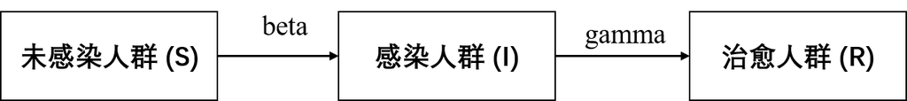

SIR模型

尚未感染的人群，其变化率是：
$$dS / dt = - \beta \cdot S \cdot I$$
感染人群的变化率是：
$$dI / dt = \beta \cdot S \cdot I - \gamma \cdot I$$
治愈人群的变化率是：
$$dR / dt = \gamma \cdot I$$
参数$\beta$是每个宿主每天接触到的人数（记为$c$）和接触时感染概率（记为$p$）的乘积，亦即：$\beta = c \cdot p$。参数$\gamma$为治愈率，其倒数$D = 1 / \gamma$为平均治疗时间。

```r
rm(list = ls())
suppressMessages(library(deSolve))
suppressMessages(library(ggplot2))

# basic SIR model
sir <- function(time, state, parameters) {
  with(as.list(c(state, parameters)), {
    dS <- -beta * S * I
    dI <- beta * S * I - gamma * I
    dR <- gamma * I
    return(list(c(dS, dI, dR)))
  })
}
```

根据[德国哥廷根大学于晓华教授提供的参数](https://weibo.com/u/1684992301?is_hot=1#_rnd1579701992368)，亦即$\beta = 0.2586$和$\gamma = 0.0821$求解模型，进而使用ggplot2绘制2019-nCoV的传播情况。

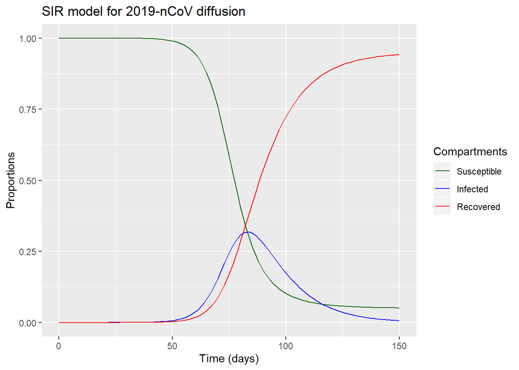

```r
# set parameter and solve the model
init <- c(S = 1 - 1e-6, I = 1e-6,R = 0)
parameters <- c(beta = 0.2586, gamma = 0.0821)
times <- seq(0, 150, by = 1)
out <- as.data.frame(ode(y = init, times = times, func = sir, parms = parameters))
out$time <- times

# plot the diffusion of 2019-nCoV
ggplot(out, aes(x = time)) +
  geom_line(aes(y = S,colour="Susceptible")) +
  geom_line(aes(y = I,colour="Infected")) +
  geom_line(aes(y = R,colour="Recovered")) +
  ylab(label="Proportions") + xlab(label="Time (days)") +
  scale_colour_manual("Compartments", breaks=c("Susceptible","Infected","Recovered"), values=c("blue","red","darkgreen")) +
  ggtitle("SIR model for 2019-nCoV diffusion")
```

借助2003年SARS的参数，可以刻画此次2019-nCoV大体的传播情况。转折点在75天左右，亦即2020年2月20日左右达到高峰，然后逐渐得到控制。

## SIDR模型：考虑潜伏期

在SIR模型的基础上，考虑感染并处于潜伏期内的人群。因此SIIR模型将人群分为：尚未感染人群（susceptible）、感染并潜伏人群（infectious & incubated）、感染并发现且随即隔离人群（infectious & discovered）和治愈人群（recovered）。SIDR模型示意图如下：

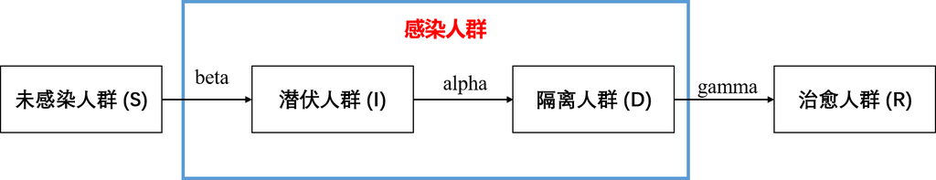

SIDR模型

尚未感染的人群，其变化率是：
$$dS / dt = - \beta \cdot S \cdot I$$
感染并潜伏人群的变化率是：
$$dI / dt = \beta \cdot S \cdot I - \alpha \cdot I$$
感染并隔离人群的变化率是：
$$dD / dt = \alpha \cdot I - \gamma \cdot D$$
治愈人群的变化率是：
$$dR / dt = \gamma \cdot D$$
参数$\beta$是每个宿主每天接触到的人数（记为$c$）和接触时感染概率（记为$p$）的乘积，亦即：$\beta = c \cdot p$。参数$\gamma$为治愈率，其倒数$1 / \gamma$为平均治疗时间。参数$\alpha$为隔离率，由于平均潜伏时间为7天，因而可知$\alpha = 1/7$。

```r
# load packages
rm(list = ls())

# SIDR model
sidr <- function(time, state, parameters) {
  with(as.list(c(state, parameters)), {
    dS <- -beta * S * I
    dI <- beta * S * I - alpha * I
    dD <- alpha * I - gamma * D
    dR <- gamma * D

    return(list(c(dS, dI, dD, dR)))
  })
}

# set parameter and solve the model
init <- c(S = 1 - 1e-6, I = 1e-6, D = 0, R = 0)
parameters <- c(beta = 0.2586, gamma = 0.0821, alpha = 0.1428)
times <- seq(0, 360, by = 1)
out <- as.data.frame(ode(y = init, times = times, func = sidr, parms = parameters))
out$time <- times
```

使用ggplot2绘制2019-nCoV的传播情况。

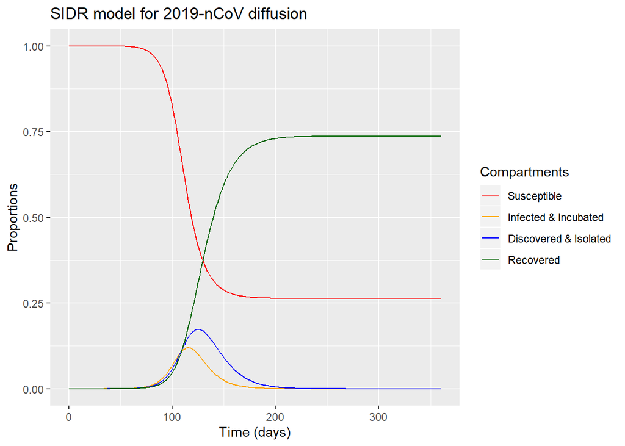

```r
# write a function to plot the diffusion of 2019-nCoV
plot.sidr <- function(out) {
  ggplot(out, aes(x = time)) +
  geom_line(aes(y = S,colour="Susceptible")) +
  geom_line(aes(y = I,colour="Infected & Incubated")) +
  geom_line(aes(y = D,colour="Discovered & Isolated")) +
  geom_line(aes(y = R,colour="Recovered")) +
  ylab(label="Proportions") + xlab(label="Time (days)") +
  scale_colour_manual("Compartments", breaks=c("Susceptible","Infected & Incubated","Discovered & Isolated","Recovered"), values=c("blue","orange","darkgreen","red")) +
  ggtitle("SIDR model for 2019-nCoV diffusion")
}

# plot the data
plot.sidr(out)
```

借助2003年SARS的参数，可以刻画此次2019-nCoV大体的传播情况。转折点在120天左右，亦即2020年4月1日左右达到高峰，然后逐渐得到控制。

当然，这一数据并不准确。不过，参数并不妨碍我们回答最关键的问题：

- 到底有多少尚未报道的感染者？

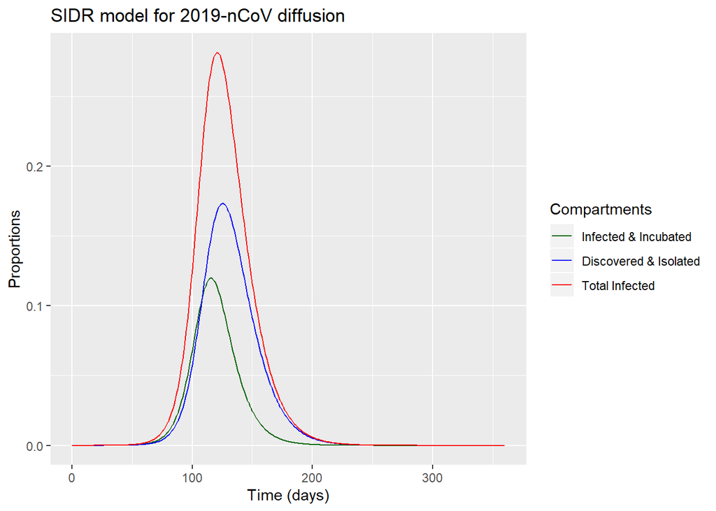

```r
# calculate total infectious
out$TI <- out$I + out$D

# plot the diffusion of 2019-nCoV
ggplot(out, aes(x = time)) +
  geom_line(aes(y = I,colour="Infected & Incubated")) +
  geom_line(aes(y = D,colour="Discovered & Isolated")) +
  geom_line(aes(y = TI,colour="Total Infected")) +
  ylab(label="Proportions") + xlab(label="Time (days)") +
  scale_colour_manual("Compartments", breaks=c("Infected & Incubated","Discovered & Isolated","Total Infected"), values=c("blue","darkgreen","red")) +
  ggtitle("SIDR model for 2019-nCoV diffusion")
```

更直接地，我们给出总感染者$TI$和被发现的感染者$D$的比例，

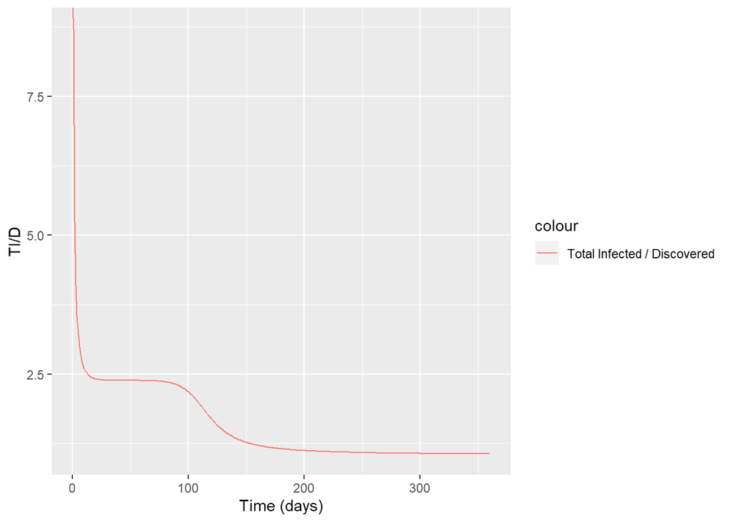

```r
# plot the diffusion of 2019-nCoV
ggplot(out, aes(x = time)) +
  geom_line(aes(y = TI / D,colour="Total Infected / Discovered")) +
  xlab(label="Time (days)")
```

可以看到，真实感染者的数量，是报道出来感染者数量的2.5倍。

## SIDR模型应用：传染率如何？

目前的SIDR模型使用的是SARS的传染率，亦即$\beta = \beta_{SARS} = 0.2586$。那么，这一传染率是被高估了，还是被低估了呢？

我们考虑两个简单的情形：

- 传染率被高估了，真实传染率$\beta = 2/3 \times \beta_{SARS}$
- 传染率被低估了，真实传染率$\beta = 3/2 \times \beta_{SARS}$

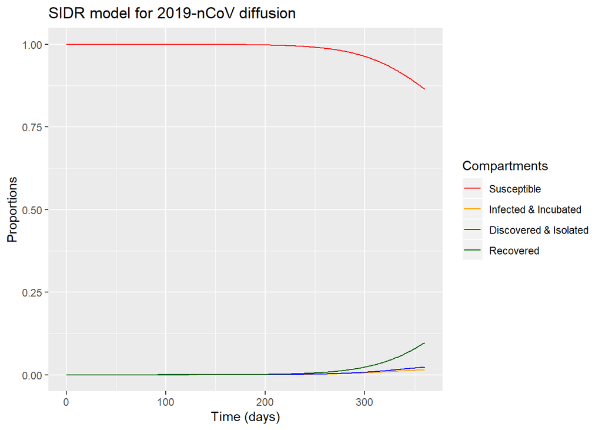

```r
# overestimated
parameters <- c(beta = 0.2586 * 2 / 3, gamma = 0.0821, alpha = 0.1428)
times <- seq(0, 360, by = 1)
out <- as.data.frame(ode(y = init, times = times, func = sidr, parms = parameters))
out$time <- times
plot.sidr(out)
```

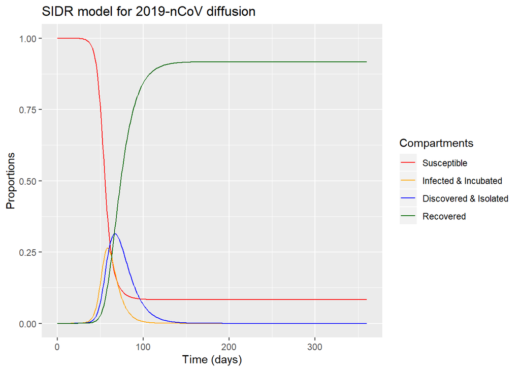

```r
# underestimated
parameters <- c(beta = 0.2586 * 3 / 2, gamma = 0.0821, alpha = 0.1428)
times <- seq(0, 360, by = 1)
out <- as.data.frame(ode(y = init, times = times, func = sidr, parms = parameters))
out$time <- times
plot.sidr(out)
```

从结果来看，传染率越低，疫情蔓延越久；反之，传染率越高，疫情蔓延越快。

显然，我们低估了2019-nCoV的传染率。更可能的情况是，2019-nCoV的传染率是SARS的1.5倍。

## SIDR模型应用：真实感染人数到底有多少？

我们更新传染率，再次给出真实感染人数和报道出来感染人数的比值，结果如下。

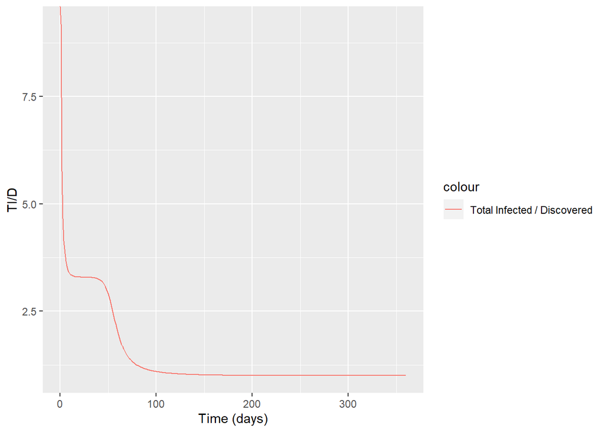

```r
# calculate total infectious
out$TI <- out$I + out$D

# plot the diffusion of 2019-nCoV
ggplot(out, aes(x = time)) +
  geom_line(aes(y = TI / D,colour="Total Infected / Discovered")) +
  xlab(label="Time (days)")
```

可以看到，在现阶段，真实感染者的数量，大约是报道出来感染者数量的3倍。